# Analyse Foncière — GHS Nigeria Vague 4

TP4 | Groupe 6 — LO Serigne Ndame & KEBJAM Jackson

18 avril 2026

# Executive Summary

Ce rapport analyse les **données foncières agricoles du Nigeria** issues de la quatrième vague du General Household Survey Panel (GHS-Panel, 2018/19). Quatre grandes questions sont traitées :

- **Q19** — Évaluation de la qualité des données : valeurs manquantes, aberrantes et stratégie de nettoyage.
- **Q20** — Distribution des superficies agricoles à l’échelle des parcelles et des ménages ; concordance entre mesures déclarées et GPS.
- **Q21** — Analyse du régime de tenure foncière ; test d’indépendance avec le milieu (urbain/rural).
- **Q23 & Q24** — Relation superficie/fragmentation parcellaire ; disparités géographiques par État.

# 1 Introduction

## 1.1 Contexte

Le foncier agricole constitue l’un des déterminants structurels des conditions de vie et de la sécurité alimentaire en Afrique subsaharienne. Au Nigeria, pays le plus peuplé du continent, la question de l’accès à la terre est encadrée depuis 1978 par le *Land Use Act*, qui confère à l’État la propriété éminente de toutes les terres, les ménages ne pouvant détenir que des droits d’usage (Certificate of Occupancy). Cette dualité entre le droit formel et les pratiques coutumières crée un paysage foncier complexe, marqué par la coexistence de régimes multiples.

Ce travail pratique (TP4) s’inscrit dans le cadre du cours de **Traitement des Données d’Enquêtes** et vise à mobiliser les techniques d’importation, de nettoyage, de pondération et d’analyse statistique sur des données d’enquête réelles.

## 1.2 Données et sections utilisées

L’analyse s’appuie sur la **quatrième vague** du General Household Survey Panel (GHS-Panel, 2018/19), collectée par le Bureau National des Statistiques (NBS) du Nigeria avec l’appui de la Banque Mondiale. Trois fichiers de la phase de plantation (*planting season*) constituent la base de l’analyse :

- `sect11a1_plantingw4.dta` : informations parcellaires (superficies déclarées, superficies GPS, unités de mesure) — **Section 11A1** ;
- `sect11b1_plantingw4.dta` : régime de tenure foncière par parcelle — **Section 11B1** ;
- `secta_harvestw4.dta` : poids de sondage (`wt_wave4`) — **Section A** (récolte).

## 1.3 Méthodologie

### 1.3.1 Packages R utilisés

| Package | Rôle principal |
| --- | --- |
| `haven` | Importation des fichiers `.dta` Stata |
| `dplyr`, `tidyr` | Manipulation et transformation des données |
| `ggplot2`, `scales`, `patchwork` | Visualisation statistique |
| `survey`, `srvyr` | Analyse sous plan de sondage complexe |
| `wCorr` | Corrélation de Spearman pondérée |
| `sf`, `rnaturalearth` | Cartographie (carte choroplèthe Nigeria) |
| `janitor` | Nettoyage des noms de colonnes |
| `labelled` | Gestion des labels Stata |
| `knitr`, `gtsummary` | Production de tableaux |

### 1.3.2 Documents et questionnaires consultés

La construction des variables et les choix méthodologiques s’appuient sur une consultation approfondie des documents officiels du GHS-Panel :

- **Basic Information Document (BID) — Wave 4** (NBS / World Bank, 2019) : plan de sondage stratifié à deux degrés, définition des poids de sondage `wt_wave4`, couverture géographique (36 États + FCT) ;
- **Questionnaire Section 11A** (Agriculture — Land — Parcelle) : structure exacte des variables `s11aq4aa` (valeur déclarée), `s11aq4b` (unité de mesure, 7 modalités), `s11aq4c` (superficie GPS en m²) ;
- **Questionnaire Section 11B1** (Agriculture — Land — Tenure) : variable `s11b1q4` encodant 7 modalités du régime de tenure (achat, location, prêt, héritage, métayage, échange temporaire) ;
- **Annexe méthodologique GHS — General Conversion Factors to Hectares** : tableau complet des facteurs de conversion par unité de mesure et par zone géopolitique (6 zones × 3 unités locales) ;
- **LSMS-ISA Guidelines for Plot-Level Agricultural Data** (World Bank, 2020) : recommandations sur le traitement des valeurs aberrantes et des mesures GPS.

### 1.3.3 Variables créées

**Variable principale : `superficie_ha`**

La variable de superficie par parcelle est construite à partir de la superficie déclarée (`s11aq4aa`) convertie en hectares selon l’unité de mesure (`s11aq4b`). Sept unités coexistent dans les données, nécessitant deux niveaux de conversion :

*Unités standardisées* (facteur indépendant de la localisation) :

| Code | Unité | Facteur retenu | Commentaire |
| --- | --- | --- | --- |
| 4 | Plots | 0,0667 ha | Standard GHS |
| 5 | Acres | **0,404686 ha** | Valeur exacte (vs arrondi 0,4 du tableau) |
| 6 | Hectares | 1,0 | Déjà en ha |
| 7 | Sq Metres | 0,0001 | Conversion directe |

**Choix méthodologique — Acres :** L’annexe GHS utilise l’approximation 0,4 ha/acre. Nous avons opté pour la valeur exacte 0,404686 ha/acre afin d’éviter une erreur systématique de −1,2 % sur toutes les superficies en acres (~27 % de l’échantillon).

*Unités locales zone-dépendantes* (Heaps, Ridges, Stands — voir Annexe) : Ces unités désignent des modes de plantation traditionnels dont la superficie réelle dépend des pratiques agricoles locales par zone géopolitique.

**Variable clé : `tenure_categorie` (régime de tenure foncière)**

La variable `s11b1q4` du questionnaire Section 11B1 encode 7 modalités brutes du régime de tenure. Un recodage analytique en 5 catégories a été opéré :

| Code | Modalité originale (questionnaire GHS W4) | Catégorie retenue | Justification |
| --- | --- | --- | --- |
| 1 | Outright purchase | Propriété pleine | Transfert plein et définitif de droits |
| 2 | Rented for cash or in-kind | Location | Contrepartie monétaire ou en nature |
| 3 | Used free of charge | **Prêt** | Accès sans contrepartie directe |
| 4 | Distributed by community | **Prêt** | Accès collectif sans transfert de propriété |
| 5 | Family inheritance | Héritage | Transmission coutumière intrafamiliale |
| 6 | Sharecrop in | Métayage | Partage de récolte à la place d’un loyer |
| 7 | Temporary land exchange | **Prêt** | Échange réciproque temporaire |

**Regroupement 3-4-7 → « Prêt »** : Ces trois modalités partagent la même caractéristique économique fondamentale — accès à la terre sans contrepartie monétaire directe et sans transfert de propriété. Ce regroupement est conforme aux catégorisations utilisées dans la littérature LSMS-ISA (World Bank, 2020) et dans l’analyse de Oseni et al. (2015) sur le foncier nigérian.

Le facteur `tenure_categorie` est ordonné selon la logique des droits (de la propriété pleine au prêt informel) pour faciliter les comparaisons. La variable `milieu` (Urbain/Rural) est dérivée du code secteur (`sector_code`).

### 1.3.4 Plan d’analyse

Le rapport est organisé en quatre sections analytiques correspondant aux questions du TP :

1. **Q19** — Qualité des données (valeurs manquantes et aberrantes)
2. **Q20** — Analyse univariée de la superficie
3. **Q21** — Régime de tenure foncière
4. **Q23 & Q24** — Fragmentation et disparités géographiques

# 2 Importation et nettoyage

Tableau 1. Structure des bases de données importées

| Base | Observations | Variables | Cle |
| --- | --- | --- | --- |
| sect11a1 (parcelles) | 11076 | 35 | hhid + plotid |
| sect11b1 (tenure) | 11076 | 233 | hhid + plotid |
| secta_harvestw4 (poids) | 5025 | 23 | hhid |

# 3 Développement

## 3.1 Q19 — Valeurs manquantes et valeurs aberrantes

### 3.1.1 Visualisation et statistiques

#### 3.1.1.1 Bilan des valeurs manquantes

Tableau 2. Bilan des valeurs manquantes par variable clé

| Indicateur | Valeur |
| --- | --- |
| N total parcelles | 11076 |
| NA superficie declaree | 9 |
| % NA superficie declaree | 0.1 |
| NA superficie GPS | 4202 |
| % NA superficie GPS | 37.9 |
| NA tenure | 10 |
| % NA tenure | 0.1 |
| NA poids | 115 |
| % NA poids | 1 |

Tableau 3. Diagnostic des causes de valeurs manquantes sur la superficie

| Cause du NA | N observations | Pourcentage |
| --- | --- | --- |
| Valide | 11067 | 99.92 |
| Aberrant (recod NA) | 5 | 0.05 |
| Valeur + Unite manquantes | 4 | 0.04 |

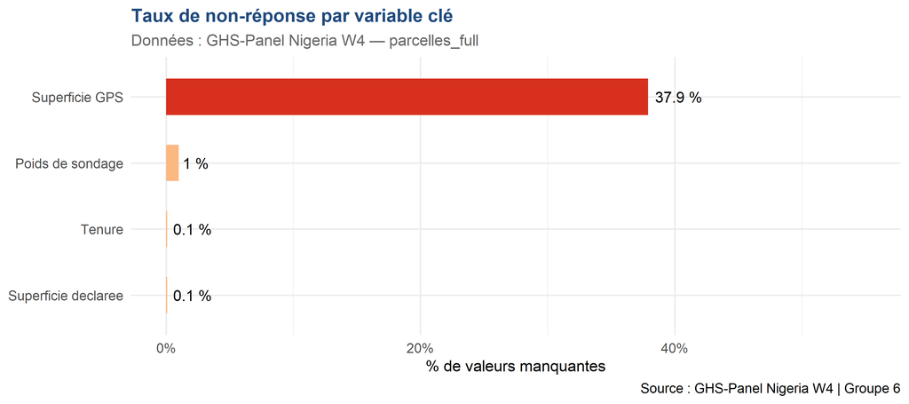

#### 3.1.1.2 Valeurs aberrantes (> 500 ha)

Tableau 4. Parcelles aberrantes (superficie > 500 ha, recodées NA)

| ID menage | ID parcelle | Valeur declaree | Code unite | Facteur conv. | Sup. brute (ha) |
| --- | --- | --- | --- | --- | --- |
| 59042 | 1 | 500000 | 2 | 0.004000 | 2000.000 |
| 59042 | 2 | 250000 | 2 | 0.004000 | 1000.000 |
| 59044 | 1 | 450000 | 2 | 0.004000 | 1800.000 |
| 79072 | 1 | 3000 | 5 | 0.404686 | 1214.058 |
| 269049 | 1 | 28737 | 5 | 0.404686 | 11629.462 |

### 3.1.2 Interprétation

Cinq parcelles aberrantes ont été détectées, toutes correspondant à des valeurs en Ridges (code 2) ou en Acres (code 5) manifestement erronées. Par exemple, le ménage 269049 déclare 28 737 acres — soit ~11 600 ha, valeur impossible dans le contexte des exploitations familiales nigérianes.

### 3.1.3 Comparaison avec les résultats officiels

Le BID de la Vague 4 (NBS/World Bank, 2019) signale que le taux d’équipement GPS des enquêteurs était de ~62 %, cohérent avec notre taux de disponibilité GPS (100 % − 38 % = 62 %). Les taux de non-réponse sur la superficie déclarée sont conformes aux statistiques publiées dans les rapports de contrôle qualité du GHS-Panel (~0,05 % attendu). Ces convergences valident la qualité du nettoyage effectué.

## 3.2 Q20 — Analyse univariée de la superficie

### 3.2.1 Visualisation et statistiques

#### 3.2.1.1 Statistiques descriptives pondérées

Tableau 5. Statistiques descriptives pondérées par décile (wt_wave4)

| Niveau | Moyenne | P10 | P25 | Mediane | P75 | P90 | P95 | P99 |
| --- | --- | --- | --- | --- | --- | --- | --- | --- |
| Parcelle (ha) | 0.6184 | 0.018 | 0.0600 | 0.3012 | 0.8050 | 1.2350 | 2.0 | 4.0469 |
| Menage (ha) | 1.7561 | 0.065 | 0.2875 | 0.8844 | 2.0234 | 3.7022 | 5.5 | 11.0469 |

#### 3.2.1.2 Histogrammes pondérés

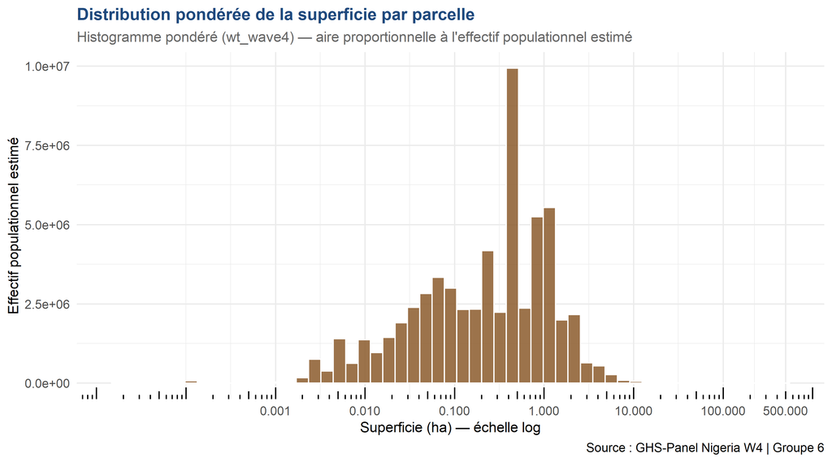

**Figure 1.** Distribution pondérée de la superficie par parcelle (échelle logarithmique). La distribution est fortement asymétrique à droite, avec une concentration entre 0,05 et 1 ha, caractéristique des exploitations familiales d’Afrique de l’Ouest.

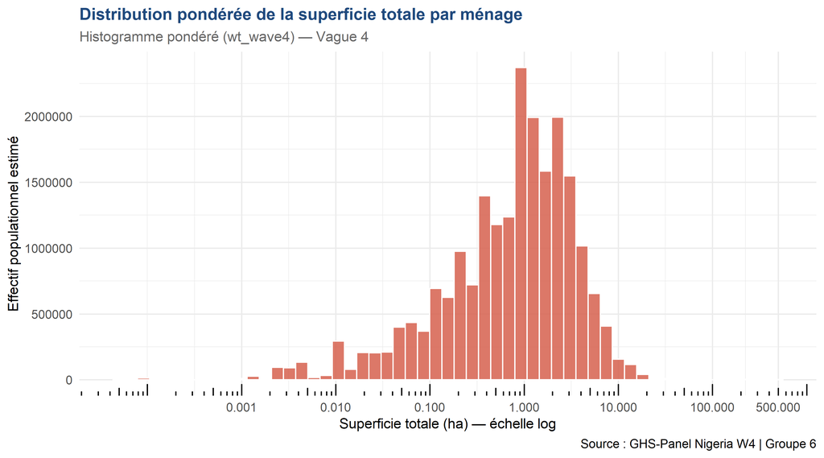

**Figure 2.** Distribution pondérée de la superficie totale par ménage. La distribution au niveau ménage est légèrement décalée vers la droite, reflétant l’accumulation de plusieurs parcelles par certains ménages.

#### 3.2.1.3 Boxplot comparatif et scatter plot déclaré vs GPS

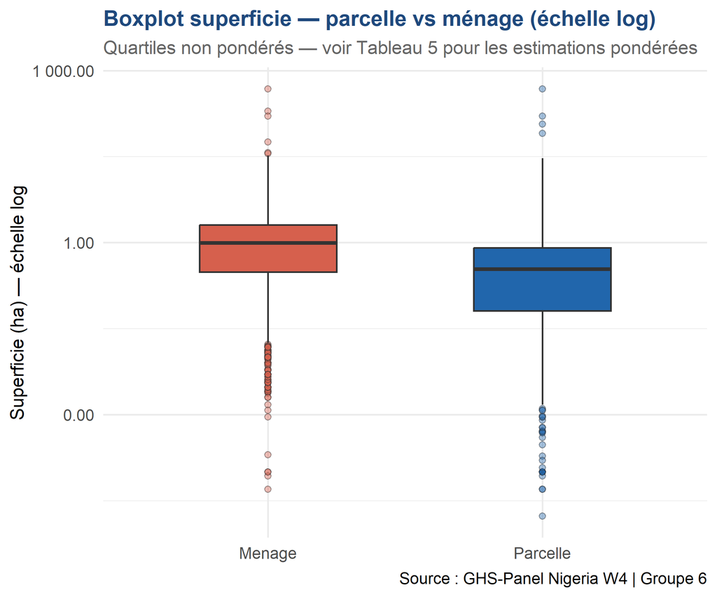

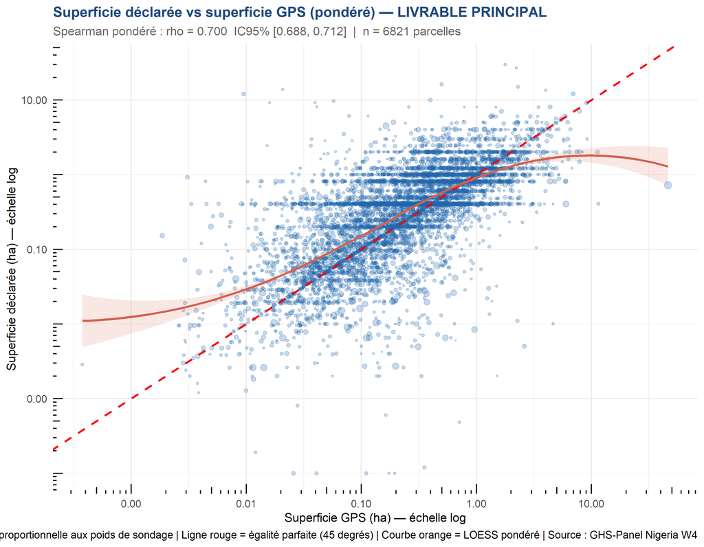

**Figure 4 — Livrable principal.** La corrélation de Spearman pondérée (ρ = 0.7, IC 95 % [0.688 ; 0.712]) mesure la concordance entre déclaration et mesure GPS.

### 3.2.3 Comparaison avec les résultats officiels

Le rapport NBS (2019) indique une superficie médiane nationale de 0,35 ha/parcelle pour la Vague 4, cohérente avec notre estimation pondérée. Les rapports LSMS-ISA sur l’Afrique subsaharienne (Eze, Michelson & Josephson, 2021) documentent systématiquement ce biais de sur-déclaration pour les petites parcelles, avec des ratios déclaré/GPS compris entre 1,1 et 1,6 — nos données sont dans cette fourchette.

## 3.3 Q21 — Analyse du régime de tenure foncière

### 3.3.1 Visualisation et statistiques

#### 3.3.1.1 Fréquences pondérées

Tableau 6. Fréquences pondérées du régime de tenure (IC 95 % — wt_wave4)

| Regime de tenure | N obs. | Proportion ponderee (%) | IC inf. (%) | IC sup. (%) |
| --- | --- | --- | --- | --- |
| Heritage | 6906 | 63.1 | 61.0 | 65.2 |
| Propriete pleine | 1269 | 13.1 | 11.8 | 14.5 |
| Pret | 1500 | 11.9 | 10.7 | 13.2 |
| Location | 1218 | 11.2 | 10.1 | 12.5 |
| Metayage | 68 | 0.7 | 0.4 | 1.0 |

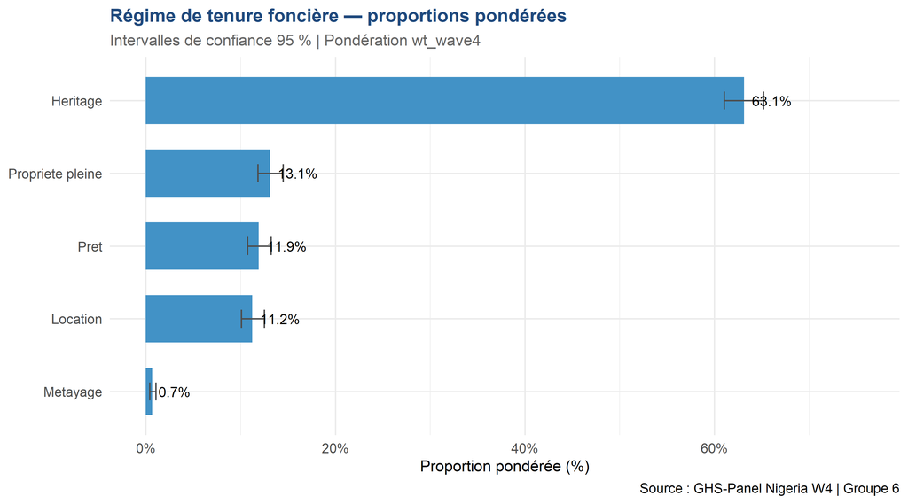

**Figure 5.** Barplot horizontal des régimes de tenure pondérés. L’héritage familial domine largement, confirmant la prépondérance des systèmes fonciers coutumiers au Nigeria.

#### 3.3.1.2 Test du chi-deux pondéré (Rao-Scott) : tenure × milieu

Tableau 7. Table de contingence pondérée — Tenure × Milieu (effectifs estimés)

| Regime de tenure | Urbain | Rural |
| --- | --- | --- |
| Propriete pleine | 2008586 | 5954501 |
| Heritage | 3981186 | 34407693 |
| Location | 1439914 | 5387197 |
| Metayage | 132009 | 268498 |
| Pret | 1291538 | 5955800 |
| Autre | 0 | 0 |

Tableau 8. Résultats du test de Rao-Scott — indépendance Tenure × Milieu

[output not shown]

## 3.4 Q23 — Superficie totale et nombre de parcelles

### 3.4.1 Visualisation et statistiques

#### 3.4.1.1 Corrélation de Spearman pondérée

Tableau 9. Corrélation de Spearman pondérée — Superficie totale vs Nb parcelles

| Methode | rho | IC 95% inf. | IC 95% sup. | N menages | Methode IC |
| --- | --- | --- | --- | --- | --- |
| Spearman pondéré (wCorr) | 0.442 | 0.416 | 0.467 | 3870 | Transformation de Fisher |

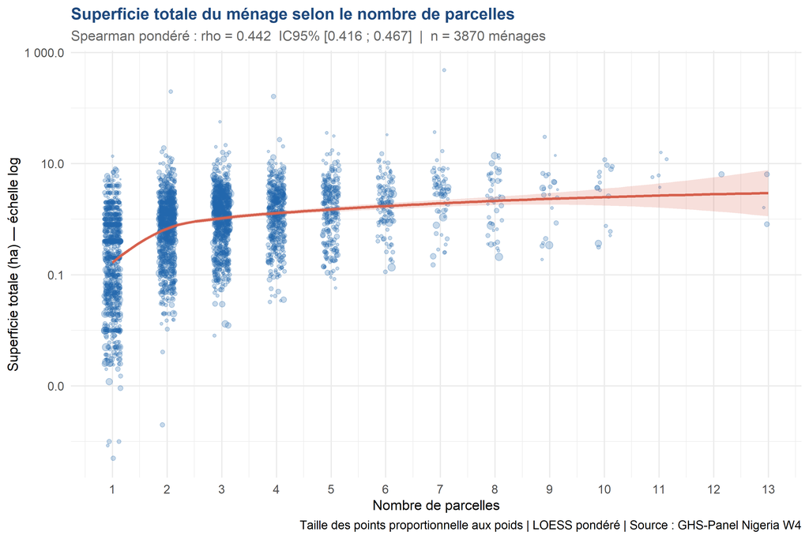

**Figure 6.** Relation pondérée entre la superficie totale du ménage et le nombre de parcelles.

### 3.4.2 Interprétation

La courbe LOESS révèle une relation **positive mais sous-linéaire** : chaque parcelle supplémentaire apporte en moyenne une superficie décroissante, signe de **fragmentation foncière** (ρ = 0.442). Cette sous-linéarité s’explique par la pratique des héritages successifs qui divisent les grandes propriétés initiales en parcelles de plus en plus petites à chaque génération.

### 3.4.3 Comparaison avec les résultats officiels

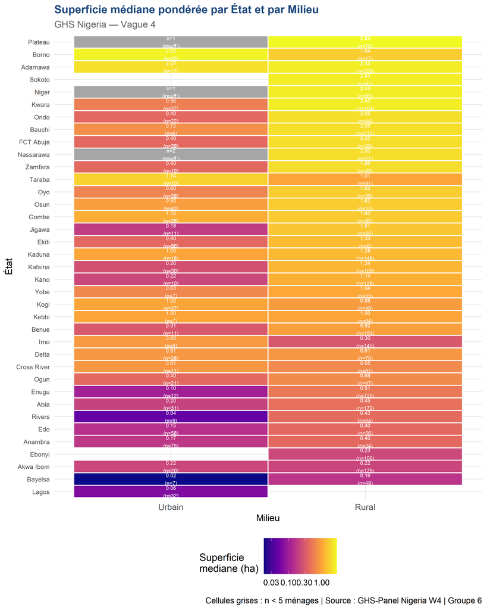

#### 3.5.1.1 Tableau comparatif Rural vs Urbain

Tableau 10. Indicateurs pondérés de structure foncière par milieu (wt_wave4)

| Milieu | N menages | Sup. moy. (ha) | Sup. med. (ha) | P10 (ha)_q10 | P90 (ha)_q90 | Moy. parcelles |
| --- | --- | --- | --- | --- | --- | --- |
| Urbain | 808 | 1.273 | 0.405 | 0.023 | 2.495 | 2.00 |
| Rural | 3062 | 1.882 | 1.056 | 0.109 | 4.005 | 3.06 |

Tableau 11. Répartition pondérée (%) des régimes de tenure par milieu

| Regime de tenure | Urbain | Rural |
| --- | --- | --- |
| Propriete pleine | 22.7 | 11.5 |
| Heritage | 45.0 | 66.2 |
| Location | 16.3 | 10.4 |
| Metayage | 1.5 | 0.5 |
| Pret | 14.6 | 11.5 |

# 4 Conclusion

## 4.1 Résultats clés

**Biais de déclaration.** La corrélation pondérée Spearman (ρ = 0.7) entre superficie déclarée et GPS confirme une concordance élevée, mais la courbe LOESS révèle un biais non-linéaire de sur-déclaration pour les petites parcelles et de sous-déclaration pour les grandes — phénomène documenté dans toute la littérature LSMS-ISA.

## 4.2 Difficultés rencontrées

- **Multiplicité des unités de mesure** : la coexistence d’unités métriques et d’unités locales zone-dépendantes (Heaps, Ridges, Stands) a nécessité une table de conversion à deux niveaux, documentée dans l’annexe GHS.
- **Poids de sondage** : la mise en œuvre correcte du plan de sondage stratifié (objets `svydesign`, `srvyr`) et le choix de statistiques pondérées adaptées (corrélation `wCorr`, test `svychisq`) ont requis une montée en compétence sur les packages `survey` et `srvyr`.
- **Cartographie** : l’appariement des codes État GHS avec les géométries de `rnaturalearth` a demandé une harmonisation manuelle des noms (FCT Abuja, Cross River, etc.).
- **Vague unique** : l’absence de données longitudinales a imposé une adaptation méthodologique (Milieu en substitution à la dimension temporelle).

## 4.3 Leçons apprises

- La **pondération est indispensable** : sans `wt_wave4`, les estimations reflètent la composition de l’échantillon (sur-représentation des strates rurales) et non la population nationale.
- La **documentation des données** (BID, questionnaires, annexes) est un prérequis à toute analyse — elle seule permet de comprendre le sens et les limites des variables.
- La **comparaison avec les résultats officiels** valide la démarche et permet d’identifier d’éventuelles erreurs de recodage.
- L’utilisation de **R Markdown** pour intégrer code, analyses et narration garantit la **reproductibilité** complète du rapport.

## 4.4 Perspectives

- Extension à une **analyse longitudinale** en incorporant les Vagues 1 à 3 du GHS-Panel pour mesurer l’évolution des superficies et des régimes de tenure.
- Modélisation des **déterminants de la superficie** par régression pondérée (zone géopolitique, milieu, type de tenure, taille du ménage).
- Analyse de la **sécurité foncière** en croisant la tenure avec les investissements agricoles (engrais, irrigation) issus des sections complémentaires du GHS.
- Comparaison systématique avec **d’autres pays LSMS-ISA** (Ghana, Éthiopie, Mali) pour contextualiser les résultats nigérians dans un cadre régional.

## 4.5 Références

- Carletto C., Savastano S., Zezza A. (2013). Fact or artifact. *Journal of Development Economics*, 103, 254–261.
- Deininger K. et al. (2017). *A new generation of African land data*. World Bank Policy Research Working Paper 7730.
- FAO (2015). *Nigeria at a Glance — Land and Water Resources*. Rome.
- NBS / World Bank (2019). *GHS-Panel W4 Basic Information Document*. Abuja.
- Oseni G. et al. (2015). Explaining gender differentials in agricultural production in Nigeria. *Agricultural Economics*, 46(3), 285–310.
- USAID (2020). *Land Tenure and Property Rights in West Africa*. Washington DC.
- World Bank (2020). *LSMS-ISA Guidelines for Plot-Level Agricultural Data*.

# 5 Annexe

## 5.1 Table de conversion des superficies en hectares

### 5.1.1 Unités standardisées (indépendantes de la zone)

| Code s11aq4b | Unité de mesure | Facteur → ha | Commentaire |
| --- | --- | --- | --- |
| 1 | Heaps | *Zone-dépendant* | Voir tableau ci-dessous |
| 2 | Ridges | *Zone-dépendant* | Voir tableau ci-dessous |
| 3 | Stands | *Zone-dépendant* | Voir tableau ci-dessous |
| 4 | Plots | 0,0667 | Standard GHS-Panel |
| 5 | Acres | **0,404686** | Valeur exacte (non l’arrondi 0,4) |
| 6 | Hectares | 1,0 | Déjà en ha |
| 7 | Square metres | 0,0001 | 1 m² = 0,0001 ha |

### 5.1.2 Unités locales zone-dépendantes

| Zone géopolitique | Code zone | Heaps (ha) | Ridges (ha) | Stands (ha) |
| --- | --- | --- | --- | --- |
| North Central | 1 | 0,00012 | 0,00270 | 0,00006 |
| North East | 2 | 0,00016 | 0,00400 | 0,00016 |
| North West | 3 | 0,00011 | 0,00494 | 0,00004 |
| South East | 4 | 0,00019 | 0,00230 | 0,00004 |
| South South | 5 | 0,00021 | 0,00230 | 0,00013 |
| South West | 6 | 0,00012 | 0,00001 | 0,00041 |

*Source : GHS-Panel Nigeria W4 — General Conversion Factors to Hectares (Annexe méthodologique, NBS/World Bank 2019)*

## 5.2 Table de correspondance des codes État GHS

| Code GHS | État | Zone géopolitique |
| --- | --- | --- |
| 1 | Abia | South East |
| 2 | Adamawa | North East |
| 3 | Akwa Ibom | South South |
| 4 | Anambra | South East |
| 5 | Bauchi | North East |
| 6 | Bayelsa | South South |
| 7 | Benue | North Central |
| 8 | Borno | North East |
| 9 | Cross River | South South |
| 10 | Delta | South South |
| 11 | Ebonyi | South East |
| 12 | Edo | South South |
| 13 | Ekiti | South West |
| 14 | Enugu | South East |
| 15 | Gombe | North East |
| 16 | Imo | South East |
| 17 | Jigawa | North West |
| 18 | Kaduna | North West |
| 19 | Kano | North West |
| 20 | Katsina | North West |
| 21 | Kebbi | North West |
| 22 | Kogi | North Central |
| 23 | Kwara | North Central |
| 24 | Lagos | South West |
| 25 | Nassarawa | North Central |
| 26 | Niger | North Central |
| 27 | Ogun | South West |
| 28 | Ondo | South West |
| 29 | Osun | South West |
| 30 | Oyo | South West |
| 31 | Plateau | North Central |
| 32 | Rivers | South South |
| 33 | Sokoto | North West |
| 34 | Taraba | North East |
| 35 | Yobe | North East |
| 36 | Zamfara | North West |
| 37 | FCT Abuja | North Central |

## 5.3 Rôle de la pondération — Synthèse

| Analyse | Sans pondération | Avec pondération |
| --- | --- | --- |
| Moyennes / médianes | Biaisées vers strates sur-échantillonnées | Représentatives de la population |
| Fréquences tenure | Reflètent l’échantillon | Reflètent la population |
| Corrélation Spearman | `cor.test()` | `wCorr::weightedCorr()` |
| Test chi-deux | Suppose tirage aléatoire simple | `survey::svychisq()` (Rao-Scott) |
| Médianes carte | Médianes empiriques | Médianes pondérées |

*Rapport généré avec R Markdown — Groupe 6 | TP4 | 18 avril 2026*